# Defense Commissary Agency Discussion

LinkedIn Profile: https://www.linkedin.com/in/mattdeloia/

## Introduction

Purpose & Goal: Understand what opportunities exist to support DeCA through data science. Describe and demonstrate an opportunity to improve dietary choices for patrons.

Problem Statement: How to use food selection data recorded by commissaries and available through the MyCommissary portal.

Hypothesis to test: Nutrition focused reporting on grocery purchases has no impact on servicemembers or veterans’ food selections and eating habits.

## Background (1 of 2)

- 50% of American adults have preventable disease related to eating patterns and physical activity (heart disease, high blood pressure, type 2 diabetes, cancers).
- Diabetes affects nearly 25 percent of VA’s patient population and is the leading cause of blindness, end-stage renal disease, and amputation for VA patients.
- Two-thirds of all adults and nearly one-third of all children and youth in the United States are either overweight or obese.

## Background (2 of 2)

- About three-fourths of the population has an eating pattern that is low in *vegetables, fruits, and oils*.
- More than half of the population is meeting or exceeding *grain and protein* recommendations.
- Most Americans exceed the recommendations for added *sugars, saturated fats, and sodium*.

## Study Proposal (1 of 2)

- Key Question: *Does regular dietary guidance and feedback impact grocery purchases and eating habits?*
- Experimental Groups: Treatment Group (dietary reports provided) and Control Group
- Treatment: ~15 nutrition reports over study duration
- Data Collection: data downloaded from MyCommissary portal + participant surveys (pre and post treatment) that collect demographic information, dietary habits, and general nutrition knowledge
- Tools: advanced statistical packages in R and Python programming languages
- Report: results and recommendations to DeCA executives

## Study Proposal (2 of 2)

- Key Data Elements: food item UPC, unit pricing, purchase totals, and calendar date recorded on shopper receipt
- Nutrition scoring: nutrition information available through Food and Nutrient Database for Dietary Studies (USDA) and commercial databases (ex. Nutrionix); data joined by UPC
- Nutrition reporting: summary report informed by 2015-2020 dietary guidelines, electronically generated and e-mailed to study participants weekly/bi-weekly
- Data analysis: data exploration, visualization, and statistical tests to accept or reject the null hypothesis; results and insights supported with empirical evidence

## Demonstration (1 of 3)

Commissary receipt details a food purchase of 100 items. This patron earned a “C” based on food component distribution.

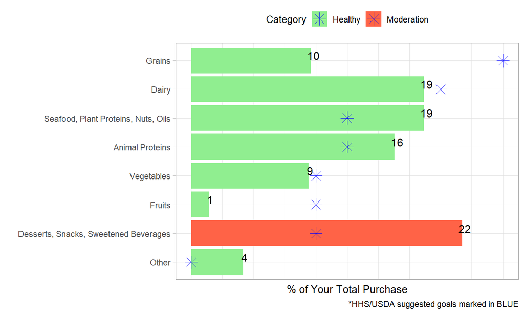

## Demonstration (2 of 3)

This patron’s healthy eating index (HEI) scores for dietary *components to limit* suggest excess in diet (100 is goal).

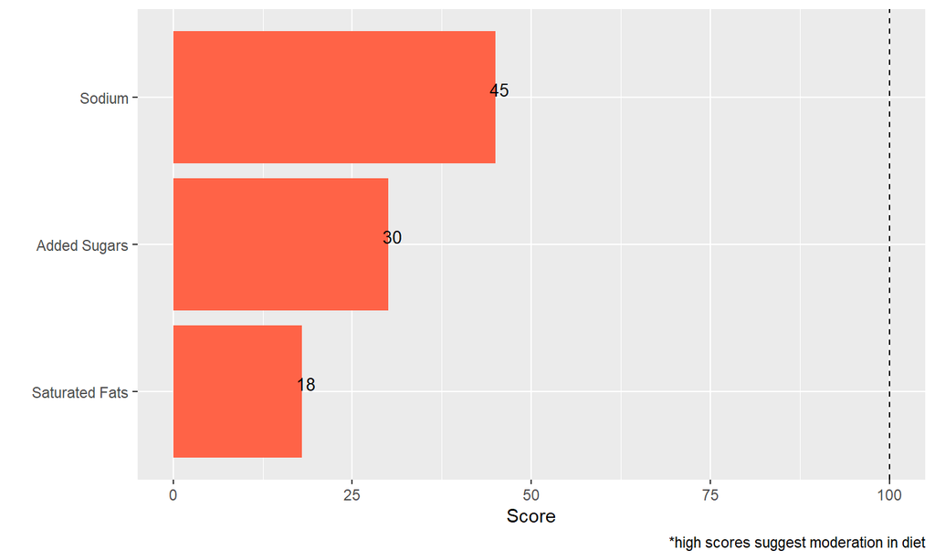

## Demonstration (3 of 3)

Select food items are highlighted due to their health benefits or detriments.

Purchases high in calcium: *1. Milk, 2% Reduced Fat; 2. French Vanilla Shake; 3. Soymilk, Organic, Unsweetened*

Purchases high in added sugars: *1. Ice Cream Bar, Double Caramel; 2. Warm Delights, Molten Chocolate Cake; 3. Pop, Jumbo Cherry With Bubble Gum Filling*

Purchases high in sodium: *1. Smoked Sausage; 2. Sausage, Smoked; 3. Sauce with Total Vegetables, Golden Curry, Hot*

## Discussion

### DeCA Analysis Needs

*For your consideration…*

1. Nutrition focused research and actions to complement DeCA’s healthy living and nutrition campaign.
2. Implementation of digitally accessible information tools.
3. Study of customer composition, satisfaction, and shopping patterns.
4. Assessment of workforce satisfaction and development of talent management tools.

## References

Dietary Guidelines for Americans 2015-2020, available at: https://health.gov/our-work/food-nutrition/2015-2020-dietary-guidelines/guidelines/

Nutiritionix, Nutrition and Exercise API, available at: https://www.nutritionix.com

R Core Team (2019). R: A language and environment for statistical computing. R Foundation for Statistical Computing, Vienna, Austria. URL https://www.R-project.org/.

Veterans Administration, Office of Research and Development, Diabetes Research, available at: https://www.research.va.gov/topics/diabetes.cfm